# Анализ поведения пользователей интернет-магазина электроники

### О проекте

Анализ поведения пользователей в интернет-магазине электроники.

**Цель**: понять, на каком этапе воронки магазин теряет пользователей, оценить удержание по когортам.

### Задачи

- Загрузить и подготовить данные о событиях пользователей;
- Построить воронку от просмотра до покупки;
- Посчитать конверсию между этапами и найти самую слабую точку;
- Сделать когортный анализ. Разбить пользователей по месяцам и посчитать Retention;
- Посмотреть, как ведут себя пользователи в разрезе сессий и категорий товаров;
- Сформулировать выводы и рекомендации.

### Данные

Взял датасет с Kaggle — события пользователей в интернет-магазине электроники.

#### `events.csv`

- `event_time` — время события;
- `event_type` — тип события (`view`, `cart`, `purchase`);
- `product_id` — ID товара;
- `category_id` — ID категории;
- `category_code` — название категории;
- `brand` — бренд;
- `price` — цена;
- `user_id` — ID пользователя;
- `user_session` — ID сессии.

### Этапы работы

1. Загрузка и просмотр данных
2. Анализ воронки
3. Когортный анализ и Retention
4. Выводы и рекомендации

## Инструменты

**Python**

- `Pandas`
- `Matplotlib`
- `seaborn`

**Источник данных:** [Kaggle](https://www.kaggle.com/datasets/mkechinov/ecommerce-events-history-in-electronics-store)

## Загрузка и проосмотр данных

```python
import pandas as pd
pd.set_option('display.max_columns', None)
pd.set_option('display.float_format', '{:,.2f}'.format)

import matplotlib.pyplot as plt
import matplotlib.dates as mdates
import seaborn as sns

import warnings
warnings.filterwarnings('ignore')
```

```python
events = pd.read_csv('data/events.csv')
start_size = events.shape[0]
```

```python
events.info()
```

```
<class 'pandas.core.frame.DataFrame'>
RangeIndex: 885129 entries, 0 to 885128
Data columns (total 9 columns):
 #   Column         Non-Null Count   Dtype
---  ------         --------------   -----
 0   event_time     885129 non-null  object
 1   event_type     885129 non-null  object
 2   product_id     885129 non-null  int64
 3   category_id    885129 non-null  int64
 4   category_code  648910 non-null  object
 5   brand          672765 non-null  object
 6   price          885129 non-null  float64
 7   user_id        885129 non-null  int64
 8   user_session   884964 non-null  object
dtypes: float64(1), int64(3), object(5)
memory usage: 60.8+ MB
```

```python
events.sample(5)
```

|  | event_time | event_type | product_id | category_id | category_code | brand | price | user_id | user_session |
| --- | --- | --- | --- | --- | --- | --- | --- | --- | --- |
| 130164 | 2020-10-21 19:15:08 UTC | view | 3758903 | 2144415923107266682 | computers.peripherals.printer | hp | 376.11 | 1515915625528892118 | m6BWCv6GIs |
| 76104 | 2020-10-11 21:33:35 UTC | view | 749087 | 2144415935732122060 | NaN | NaN | 66.19 | 1515915625516512155 | UF0QJyMaSp |
| 879851 | 2021-02-27 23:52:39 UTC | view | 1282166 | 2144415973346640379 | computers.components.hdd | samsung | 60.54 | 1515915625596223978 | 23rgL9Smqy |
| 352496 | 2020-11-25 19:38:53 UTC | view | 459699 | 2144415927158964449 | NaN | NaN | 17.25 | 1515915625543804051 | 4Iu2qedhm3 |
| 696047 | 2021-01-28 08:41:11 UTC | view | 264744 | 2144415922939494519 | NaN | panasonic | 31.81 | 1515915625597944389 | vQtNWAn90A |

```python
events.isna().sum()
```

```
event_time            0
event_type            0
product_id            0
category_id           0
category_code    236219
brand            212364
price                 0
user_id               0
user_session        165
dtype: int64
```

```python
events['event_time'].min()
```

```
'2020-09-24 11:57:06 UTC'
```

```python
events['event_time'].max()
```

```
'2021-02-28 23:59:09 UTC'
```

## Предобработка

Приведем время в формате datetime и добавим дополнительные столбцы.

```python
events['event_time'] = pd.to_datetime(events['event_time'])

events['event_date'] = events['event_time'].dt.date
events['event_month'] = events['event_time'].dt.to_period('M')
events['event_week'] = events['event_time'].dt.to_period('W')
```

Избавимся от строк без id сессии и дубликатов

```python
events.dropna(subset=['user_session'], inplace=True)
```

```python
print('Кол-во дублей:', events.duplicated().sum())
events = events.drop_duplicates()
```

```
Кол-во дублей: 652
```

Приведем `id` в формате `object`

```python
events[['product_id', 'category_id', 'user_id']] = events[['product_id', 'category_id', 'user_id']].astype('object')
```

Статистики по столбцам

```python
events.describe(include='object').T
```

|  | count | unique | top | freq |
| --- | --- | --- | --- | --- |
| event_type | 884312 | 3 | view | 792943 |
| product_id | 884312 | 53452 | 1821813 | 14551 |
| category_id | 884312 | 718 | 2144415922427789416 | 116606 |
| category_code | 648311 | 107 | computers.components.videocards | 116606 |
| brand | 672118 | 999 | asus | 27657 |
| user_id | 884312 | 407237 | 1515915625554995474 | 572 |
| user_session | 884312 | 490398 | nFlhu5QzOd | 572 |
| event_date | 884312 | 158 | 2020-11-18 | 8023 |

```python
print('Удалено строк', start_size - events.shape[0])
print('Доля оставшихся строк:', round(events.shape[0] / start_size, 4))
```

```
Удалено строк 817
Доля оставшихся строк: 0.9991
```

## Анализ пользовательской активности

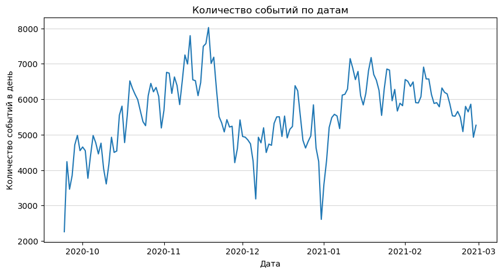

```python
daily_events = events.groupby('event_date')['event_type'].count()

daily_events.plot(kind='line', figsize=(10,5))

plt.title('Количество событий по датам')
plt.xlabel('Дата')
plt.ylabel('Количество событий в день')
plt.grid(axis='y', alpha=0.5)
plt.show()
```

```python
daily_events.describe()
```

```
count     158.00
mean    5,596.91
std       990.36
min     2,262.00
25%     4,928.00
50%     5,650.50
75%     6,300.50
max     8,023.00
Name: event_type, dtype: float64
```

## Продуктовая воронка

```python
funnel = events.groupby('event_type')['user_id'].nunique().reindex(['view', 'cart', 'purchase'])
```

```python
funnel_conv = pd.DataFrame({
    'users': funnel,
    'conversion':[
        1,
        funnel['cart'] / funnel['view'],
        funnel['purchase'] / funnel['cart']
    ]
})
funnel_conv
```

| event_type | users | conversion |
| --- | --- | --- |
| view | 406817 | 1.00 |
| cart | 36948 | 0.09 |
| purchase | 21304 | 0.58 |

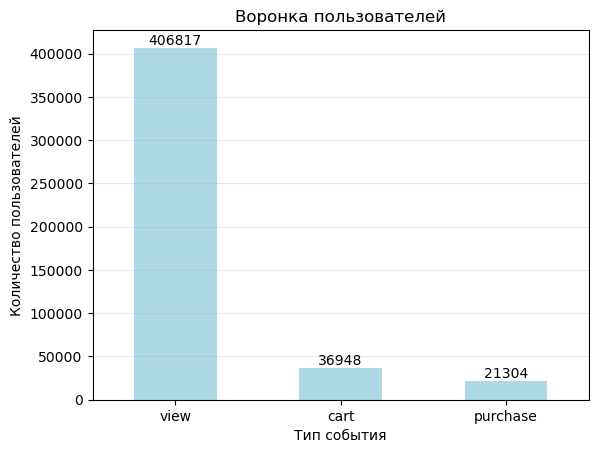

```python
funnel_conv.plot(kind='bar', y='users', rot=0, color='lightblue', legend=False)

for i, v in enumerate(funnel_conv['users'].values):
    plt.text(i, v, str(v), ha='center', va='bottom')

plt.title('Воронка пользователей')
plt.xlabel('Тип события')
plt.ylabel('Количество пользователей')
plt.grid(axis='y', alpha=0.3)
plt.show()
```

#### Вывод

Основная проблема воронки находится на этапе перехода от просмотра товара к добавлению в корзину. Только `9.08%` пользователей после просмотра добавляют товар в корзину. При этом среди пользователей, добавивших товар в корзину, конверсия в покупку составляет `57.66%`.

## Когортный анализ событий пользователей

Формируем когорты по месяцу первого события

```python
first_event= events.groupby('user_id')['event_time'].min().reset_index()
first_event['cohort_month'] = first_event['event_time'].dt.to_period('M')

events = events.merge(first_event[['user_id', 'cohort_month']] ,on='user_id', how='left')
```

Размер когорт

```python
cohort_size = events.groupby('cohort_month')['user_id'].nunique()
cohort_size
```

```
cohort_month
2020-09    15333
2020-10    83249
2020-11    90089
2020-12    69467
2021-01    78270
2021-02    70829
Freq: M, Name: user_id, dtype: int64
```

Определяем время жизни пользователя - номер месяца относительно когорты

```python
events['lifetime'] = (events['event_month'].astype(int) - events['cohort_month'].astype(int))
```

Количество активных пользователей по когортам

```python
cohort_users = events.groupby(['cohort_month', 'lifetime'])['user_id'].nunique().reset_index()
```

```python
cohort_users['retention'] = cohort_users['user_id'] / cohort_users['cohort_month'].map(cohort_size)
cohort_users[['cohort_month', 'lifetime']].drop_duplicates()
```

|  | cohort_month | lifetime |
| --- | --- | --- |
| 0 | 2020-09 | 0 |
| 1 | 2020-09 | 1 |
| 2 | 2020-09 | 2 |
| 3 | 2020-09 | 3 |
| 4 | 2020-09 | 4 |
| 5 | 2020-09 | 5 |
| 6 | 2020-10 | 0 |
| 7 | 2020-10 | 1 |
| 8 | 2020-10 | 2 |
| 9 | 2020-10 | 3 |
| 10 | 2020-10 | 4 |
| 11 | 2020-11 | 0 |
| 12 | 2020-11 | 1 |
| 13 | 2020-11 | 2 |
| 14 | 2020-11 | 3 |
| 15 | 2020-12 | 0 |
| 16 | 2020-12 | 1 |
| 17 | 2020-12 | 2 |
| 18 | 2021-01 | 0 |
| 19 | 2021-01 | 1 |
| 20 | 2021-02 | 0 |

Матрица удержания

```python
retention_matrix = cohort_users.pivot(index='cohort_month', columns='lifetime', values='retention')
retention_matrix
```

| lifetime cohort_month | 0 | 1 | 2 | 3 | 4 | 5 |
| --- | --- | --- | --- | --- | --- | --- |
| 2020-09 | 1.00 | 0.06 | 0.02 | 0.01 | 0.01 | 0.00 |
| 2020-10 | 1.00 | 0.03 | 0.01 | 0.01 | 0.00 | NaN |
| 2020-11 | 1.00 | 0.02 | 0.01 | 0.01 | NaN | NaN |
| 2020-12 | 1.00 | 0.02 | 0.01 | NaN | NaN | NaN |
| 2021-01 | 1.00 | 0.03 | NaN | NaN | NaN | NaN |
| 2021-02 | 1.00 | NaN | NaN | NaN | NaN | NaN |

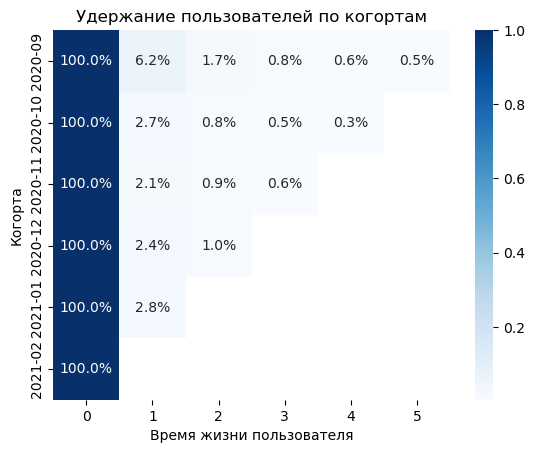

```python
sns.heatmap(retention_matrix, annot=True, fmt='.1%', cmap='Blues')

plt.title('Удержание пользователей по когортам')
plt.xlabel('Время жизни пользователя')
plt.ylabel('Когорта')
plt.show()
```

#### Вывод

С 0 по 1 месяц теряется от 93.7% до 97.9% процентов пользователей. В последующие месяца отток ослабевает и удержание стабилизуертся на уровне от 0.3 % до 1.7 %

#### Доля пользователей с повторной покупкой

Распределение количества покупок

```python
purchases = events[events.event_type == 'purchase']

purchases_per_user = (purchases.groupby('user_id')
    .size().reset_index(name='purchases'))
purchases_per_user['purchases'].describe()
```

```
count   21,304.00
mean         1.75
std          1.74
min          1.00
25%          1.00
50%          1.00
75%          2.00
max         56.00
Name: purchases, dtype: float64
```

Доля пользователей совершивших более 1 покупки

```python
repeat_purchase_rate = ((purchases_per_user['purchases'] > 1).mean())
repeat_purchase_rate
```

```
np.float64(0.36171610965076983)
```

Распределение количества пользователей по числу покупок

```python
users_per_purch = purchases.groupby('user_id').size().value_counts()
users_per_purch
```

```
1     13598
2      4292
3      1691
4       797
5       344
6       209
7        95
8        92
9        47
10       43
11       17
12       14
13       10
14        9
15        7
```

[output cut: 19 more lines]

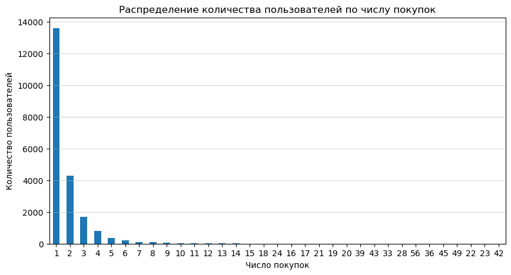

```python
users_per_purch.plot(kind='bar', rot=0, figsize=(10,5))

plt.title('Распределение количества пользователей по числу покупок')
plt.xlabel('Число покупок')
plt.ylabel('Количество пользователей')
plt.grid(axis='y', alpha=0.5)
plt.show()
```

#### Вывод

Большинство покупателей совершает только одну покупку: 63.8% пользователей не возвращаются за повторной покупкой. При этом 36.2% пользователей совершают более одной покупки. Среднее количество покупок на покупателя составляет 1.75, а медианное значение 1 покупка.

Таким образом, для магазина актуальной задачей является увеличение доли повторных покупок и удержание уже привлеченных покупателей.

## Анализ выручки

#### Расчет месячной выручки

```python
revenue = purchases['price'].sum()
revenue
```

```
np.float64(5125113.92)
```

```python
revenue_by_month = purchases.groupby('event_month')['price'].sum()
revenue_by_month
```

```
event_month
2020-09      96,353.01
2020-10     562,590.39
2020-11     787,886.24
2020-12     813,068.01
2021-01   1,488,410.57
2021-02   1,376,805.70
Freq: M, Name: price, dtype: float64
```

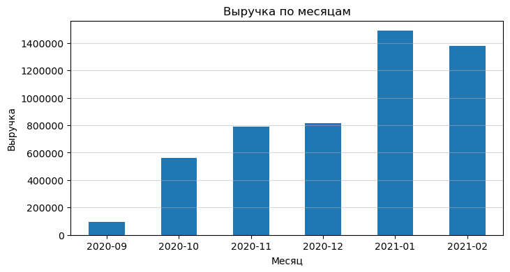

```python
revenue_by_month.plot(kind='bar', rot=0, figsize=(8,4))

plt.ticklabel_format(style='plain', axis='y')

plt.title('Выручка по месяцам')
plt.xlabel('Месяц')
plt.ylabel('Выручка')
plt.grid(axis='y', alpha=0.5)
plt.show()
```

#### Выручка по когортам

```python
cohort_revenue = (purchases.groupby(['cohort_month', 'lifetime'])['price'].sum().reset_index())
cohort_revenue
```

|  | cohort_month | lifetime | price |
| --- | --- | --- | --- |
| 0 | 2020-09 | 0 | 96,353.01 |
| 1 | 2020-09 | 1 | 26,967.41 |
| 2 | 2020-09 | 2 | 8,258.74 |
| 3 | 2020-09 | 3 | 580.84 |
| 4 | 2020-09 | 4 | 1,383.55 |
| 5 | 2020-09 | 5 | 1,521.24 |
| 6 | 2020-10 | 0 | 535,622.98 |
| 7 | 2020-10 | 1 | 46,835.55 |
| 8 | 2020-10 | 2 | 14,722.78 |
| 9 | 2020-10 | 3 | 6,874.40 |
| 10 | 2020-10 | 4 | 6,991.28 |
| 11 | 2020-11 | 0 | 732,791.95 |
| 12 | 2020-11 | 1 | 32,087.43 |
| 13 | 2020-11 | 2 | 21,581.36 |
| 14 | 2020-11 | 3 | 8,753.12 |
| 15 | 2020-12 | 0 | 765,676.96 |
| 16 | 2020-12 | 1 | 60,195.59 |
| 17 | 2020-12 | 2 | 24,004.77 |
| 18 | 2021-01 | 0 | 1,398,375.67 |
| 19 | 2021-01 | 1 | 113,872.32 |
| 20 | 2021-02 | 0 | 1,221,662.97 |

```python
revenue_matrix = cohort_revenue.pivot(index='cohort_month', columns='lifetime', values='price')
revenue_matrix
```

| lifetime cohort_month | 0 | 1 | 2 | 3 | 4 | 5 |
| --- | --- | --- | --- | --- | --- | --- |
| 2020-09 | 96,353.01 | 26,967.41 | 8,258.74 | 580.84 | 1,383.55 | 1,521.24 |
| 2020-10 | 535,622.98 | 46,835.55 | 14,722.78 | 6,874.40 | 6,991.28 | NaN |
| 2020-11 | 732,791.95 | 32,087.43 | 21,581.36 | 8,753.12 | NaN | NaN |
| 2020-12 | 765,676.96 | 60,195.59 | 24,004.77 | NaN | NaN | NaN |
| 2021-01 | 1,398,375.67 | 113,872.32 | NaN | NaN | NaN | NaN |
| 2021-02 | 1,221,662.97 | NaN | NaN | NaN | NaN | NaN |

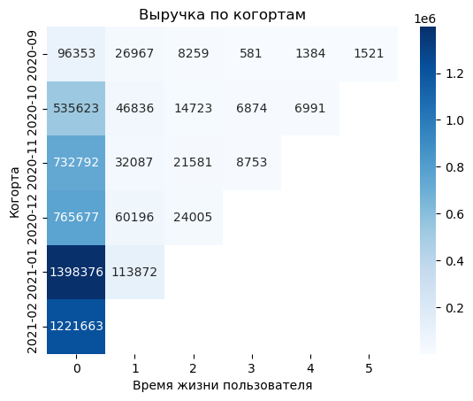

```python
sns.heatmap(revenue_matrix, annot=True, fmt='.0f', cmap='Blues')

plt.title('Выручка по когортам')
plt.xlabel('Время жизни пользователя')
plt.ylabel('Когорта')
plt.show()
```

#### ARPU по когортам

```python
cohort_arpu = cohort_revenue.merge(cohort_size.reset_index(name='users_count'), on='cohort_month')
cohort_arpu['ARPU'] = cohort_arpu['price'] / cohort_arpu['users_count']
cohort_arpu
```

|  | cohort_month | lifetime | price | users_count | ARPU |
| --- | --- | --- | --- | --- | --- |
| 0 | 2020-09 | 0 | 96,353.01 | 15333 | 6.28 |
| 1 | 2020-09 | 1 | 26,967.41 | 15333 | 1.76 |
| 2 | 2020-09 | 2 | 8,258.74 | 15333 | 0.54 |
| 3 | 2020-09 | 3 | 580.84 | 15333 | 0.04 |
| 4 | 2020-09 | 4 | 1,383.55 | 15333 | 0.09 |
| 5 | 2020-09 | 5 | 1,521.24 | 15333 | 0.10 |
| 6 | 2020-10 | 0 | 535,622.98 | 83249 | 6.43 |
| 7 | 2020-10 | 1 | 46,835.55 | 83249 | 0.56 |
| 8 | 2020-10 | 2 | 14,722.78 | 83249 | 0.18 |
| 9 | 2020-10 | 3 | 6,874.40 | 83249 | 0.08 |
| 10 | 2020-10 | 4 | 6,991.28 | 83249 | 0.08 |
| 11 | 2020-11 | 0 | 732,791.95 | 90089 | 8.13 |
| 12 | 2020-11 | 1 | 32,087.43 | 90089 | 0.36 |
| 13 | 2020-11 | 2 | 21,581.36 | 90089 | 0.24 |
| 14 | 2020-11 | 3 | 8,753.12 | 90089 | 0.10 |
| 15 | 2020-12 | 0 | 765,676.96 | 69467 | 11.02 |
| 16 | 2020-12 | 1 | 60,195.59 | 69467 | 0.87 |
| 17 | 2020-12 | 2 | 24,004.77 | 69467 | 0.35 |
| 18 | 2021-01 | 0 | 1,398,375.67 | 78270 | 17.87 |
| 19 | 2021-01 | 1 | 113,872.32 | 78270 | 1.45 |
| 20 | 2021-02 | 0 | 1,221,662.97 | 70829 | 17.25 |

```python
arpu_matrix = cohort_arpu.pivot(index='cohort_month', columns='lifetime', values='ARPU')
arpu_matrix
```

| lifetime cohort_month | 0 | 1 | 2 | 3 | 4 | 5 |
| --- | --- | --- | --- | --- | --- | --- |
| 2020-09 | 6.28 | 1.76 | 0.54 | 0.04 | 0.09 | 0.10 |
| 2020-10 | 6.43 | 0.56 | 0.18 | 0.08 | 0.08 | NaN |
| 2020-11 | 8.13 | 0.36 | 0.24 | 0.10 | NaN | NaN |
| 2020-12 | 11.02 | 0.87 | 0.35 | NaN | NaN | NaN |
| 2021-01 | 17.87 | 1.45 | NaN | NaN | NaN | NaN |
| 2021-02 | 17.25 | NaN | NaN | NaN | NaN | NaN |

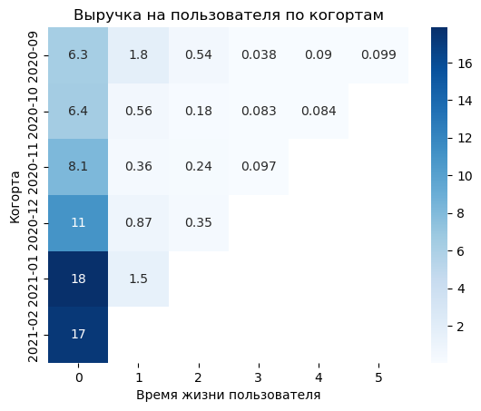

```python
sns.heatmap(arpu_matrix, annot=True, cmap='Blues')

plt.title('Выручка на пользователя по когортам')
plt.xlabel('Время жизни пользователя')
plt.ylabel('Когорта')
plt.show()
```

#### Вывод

Для всех когорт концентрация основной части выручки находится в первом месяце и после него сильно снижается. Таким образом, магазин получает основную часть дохода вскоре после привлечения пользователя, а дальнейшие покупки происходят гораздо реже.

## Анализ товаров

```python
revenye_by_category = purchases.groupby('category_code')['price'].sum().sort_values(ascending=False)
revenye_by_category.head(10)
```

```
category_code
computers.components.videocards    2,604,764.80
computers.peripherals.printer        364,566.80
computers.components.cpu             219,168.98
electronics.telephone                150,915.69
stationery.cartrige                  103,595.99
computers.components.motherboard     102,871.16
electronics.audio.acoustic            84,724.80
auto.accessories.player               81,558.66
computers.notebook                    63,604.79
electronics.video.tv                  57,987.91
Name: price, dtype: float64
```

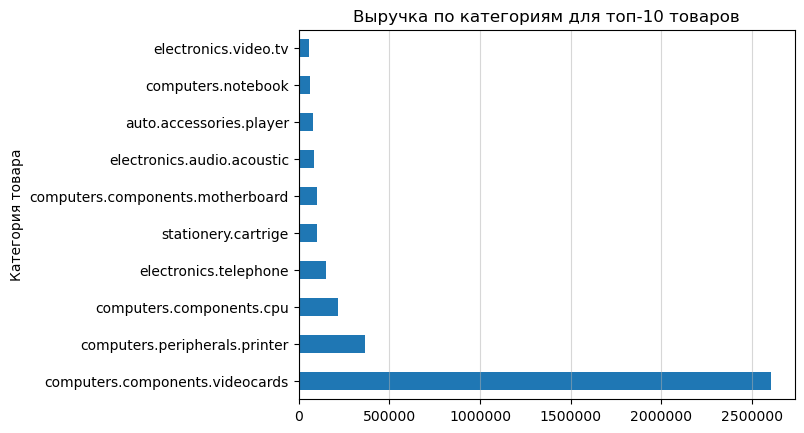

```python
revenye_by_category.head(10).plot(kind='barh')

plt.ticklabel_format(style='plain', axis='x')

plt.title('Выручка по категориям для топ-10 товаров')
plt.xlabel('')
plt.ylabel('Категория товара')
plt.grid(axis='x', alpha=0.5)
plt.show()
```

#### Вывод

Основную часть выручки формируют товары категории `computers.components.videocards` — около 2.60 млн - это значительно выше выручки по остальным категориям. На втором и третьем местах находятся `computers.peripherals.printer` и `computers.components.cpu` с выручкой 364.6 тыс. и 219.2 тыс. .

Выручка магазина сильно сконцентрирована на компьютерных комплектующих. Это делает данную категорию ключевым источником дохода, но одновременно повышает зависимость общей выручки от ее продаж.

## Итоговый вывод

В ходе исследования проанализировано поведение пользователей интернет-магазина электроники: построена продуктовая воронка, проведен когортный анализ, рассчитан retention, исследованы повторные покупки, выручка и ARPU по когортам, а также структура выручки по категориям.

Основная проблема воронки находится на этапе перехода от просмотра товара к добавлению в корзину: конверсия составляет `9.08%`. При этом из пользователей, добавивших товар в корзину, `57.66%` совершают покупку. Это означает, что наибольший потенциал для роста конверсии находится на этапе `view → cart`.

Когортный анализ показывает высокий отток пользователей после первого периода активности.

Также проблемой является повторная покупка, `63.8%` покупателей совершили только одну покупку. Доля пользователей совершивших более одной покупки составляет - `36.2%`.

ARPU в M0 вырос с `6.28` у сентябрьской когорты до `17.87` у январской, при этом, после первого месяца значение значительно снижается. Месячная выручка также в целом росла и достигла максимального значения в январе 2021 года, после чего в феврале снизилась.

Основным источником дохода является категория `computers.components.videocards` с выручкой около 2.60 млн, значительно опережающая остальные категории. Это делает категорию ключевым источником дохода, но одновременно увеличивает зависимость бизнеса от ее продаж.

Таким образом, основными направлениями для роста являются повышение конверсии из просмотра товара в добавление в корзину view → cart, увеличение доли повторных покупок и работа над удержанием пользователей после первого периода активности. Дополнительно стоит изучить факторы, которые обеспечили более высокий ARPU у поздних когорт/